# title: “Movielens”

# author: “Sijuade”

# date: “Friday, September 04, 2015”

# output: html_document

# Data Location: [linked phrase](http://grouplens.org/datasets/movielens/)

The data dictioary for this dataset is located at [linked phrase](http://files.grouplens.org/datasets/movielens/ml-100k-README.txt). The data originally downloaded was mostly in text format and had to be transformed to csv. After much wrangling, I have 3 files imported into R.

The dataset has 100,000 ratings total and 943 unique users as well as 1682 movies, The average user rated about 106 movies and the average movie was rated about 59 times. There’s a wide variance in the number ratings each movie has, some movies were rated just once and the movie with the most amount of ratings was rated 583 times.

```r
occupation = read.csv("occupation.csv")
ratings = read.csv("ratings.csv")
films = read.csv("movieinfo.csv")

occupation$X = NULL
films$X = NULL
ratings$X = NULL
```

Below is a head of all three datasets

```
##   userid age gender occupation zipcode
## 1      1  24      M technician   85711
## 2      2  53      F      other   94043
## 3      3  23      M     writer   32067
## 4      4  24      M technician   43537
## 5      5  33      F      other   15213
## 6      6  42      M  executive   98101
```

```
##   movieid                                           movietitle releasedate
## 1       1                                     Toy Story (1995) 01-Jan-1995
## 2       2                                     GoldenEye (1995) 01-Jan-1995
## 3       3                                    Four Rooms (1995) 01-Jan-1995
## 4       4                                    Get Shorty (1995) 01-Jan-1995
## 5       5                                       Copycat (1995) 01-Jan-1995
## 6       6 Shanghai Triad (Yao a yao yao dao waipo qiao) (1995) 01-Jan-1995
##   videoreleasedate
## 1               NA
## 2               NA
## 3               NA
## 4               NA
## 5               NA
## 6               NA
##                                                        imdburl unknown
```

[output cut: 27 more lines]

```
##   userid movieid rating timestamp
## 1    196     242      3 881250949
## 2    186     302      3 891717742
## 3     22     377      1 878887116
## 4    244      51      2 880606923
## 5    166     346      1 886397596
## 6    298     474      4 884182806
```

Since predicting ratings is the point of this exercise, it makes sense to combine all three into one dataset, or rather to merge the films and occupations dataset into the ratings dataset. But first we can explore the individual datasets in detail. First is a plot ratings just to get a feel of it’s distribution

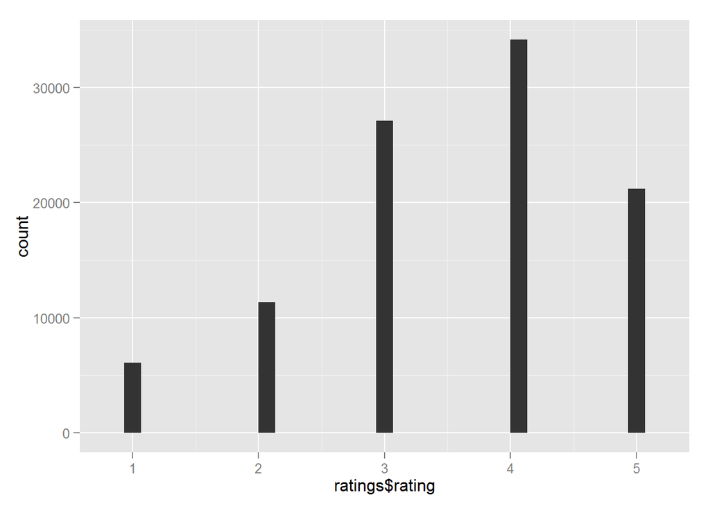

A rating of 4 looks to be the most common followed by 3 and then 5.

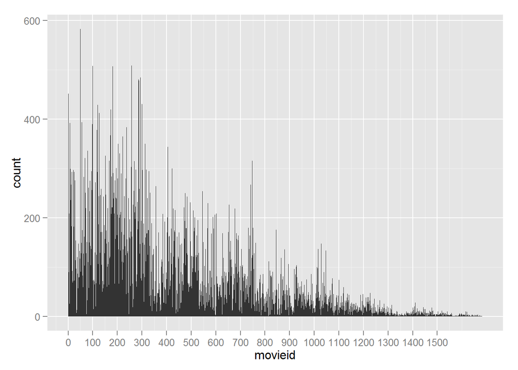

Histogram of movieid, this shows how much different ratings some movies are getting. Some movies are definitely being rated more often than others, one possible reason for this is that the movies are likely simply being viewed more times.

The following plots will look into the users

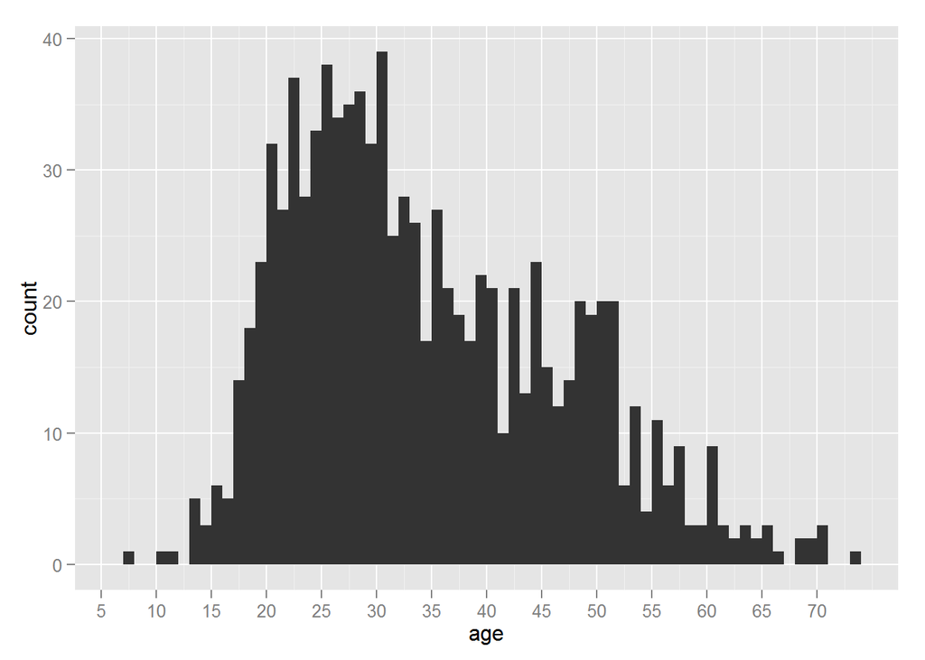

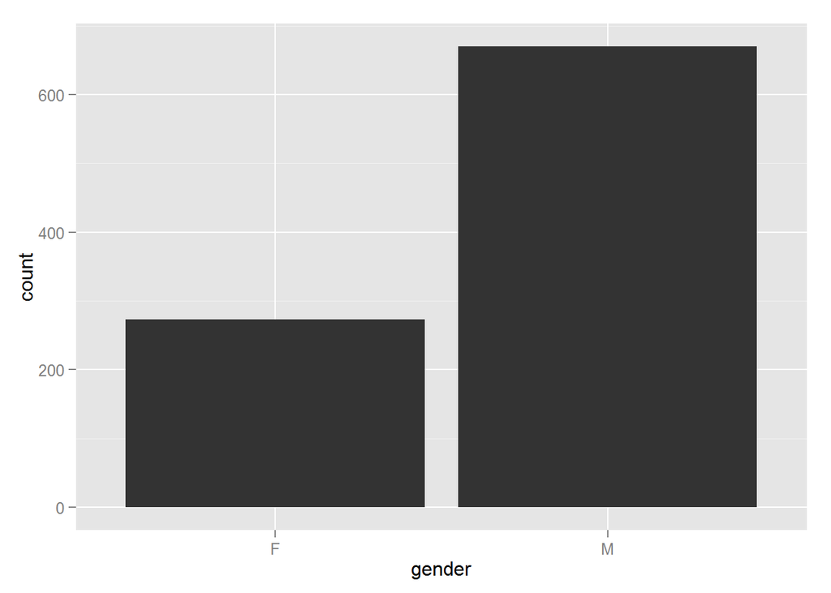

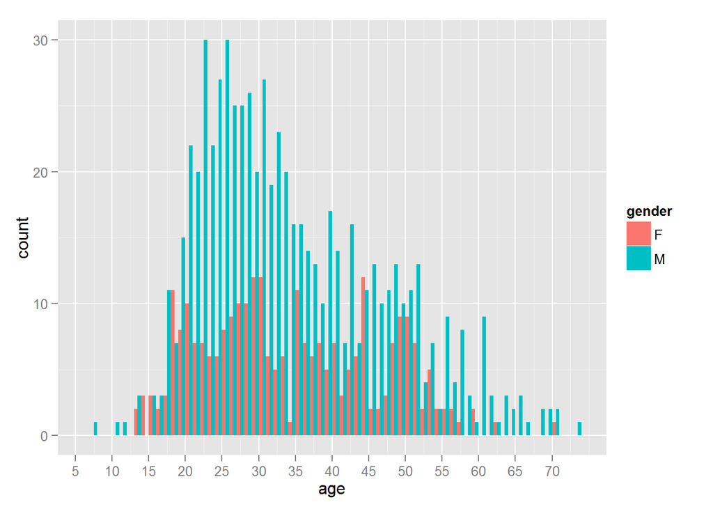

Here we see Students are the most common of users, followed by educators, administrators and engineers.

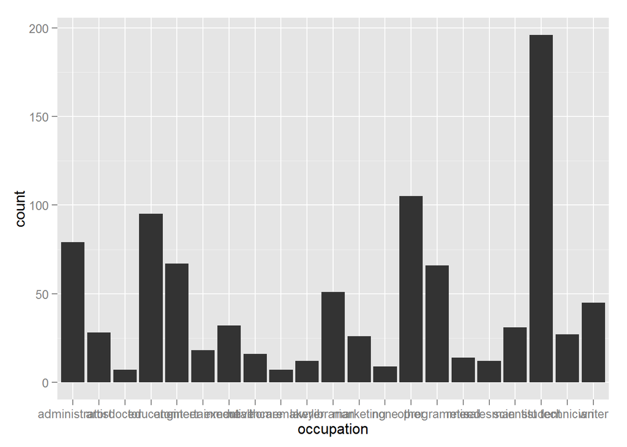

```r
qplot(occupation, data = occupation)
```

## Joining of the three datasets

Ratings and occupation are now joined, we see it’s head

```
##   userid movieid rating timestamp age gender occupation zipcode
## 1    196     242      3 881250949  49      M     writer   55105
## 2    186     302      3 891717742  39      F  executive   00000
## 3     22     377      1 878887116  25      M     writer   40206
## 4    244      51      2 880606923  28      M technician   80525
## 5    166     346      1 886397596  47      M   educator   55113
## 6    298     474      4 884182806  44      M  executive   01581
```

We can now join with the last dataset films. And also it’s head.

```
##   userid movieid rating timestamp age gender occupation zipcode
## 1    196     242      3 881250949  49      M     writer   55105
## 2    186     302      3 891717742  39      F  executive   00000
## 3     22     377      1 878887116  25      M     writer   40206
## 4    244      51      2 880606923  28      M technician   80525
## 5    166     346      1 886397596  47      M   educator   55113
## 6    298     474      4 884182806  44      M  executive   01581
##                                                                    movietitle
## 1                                                                Kolya (1996)
## 2                                                    L.A. Confidential (1997)
## 3                                                         Heavyweights (1994)
## 4                                                  Legends of the Fall (1994)
## 5                                                         Jackie Brown (1997)
## 6 Dr. Strangelove or: How I Learned to Stop Worrying and Love the Bomb (1963)
##   releasedate videoreleasedate
```

[output cut: 34 more lines]

It would make a lot more sense to split up the age into bins

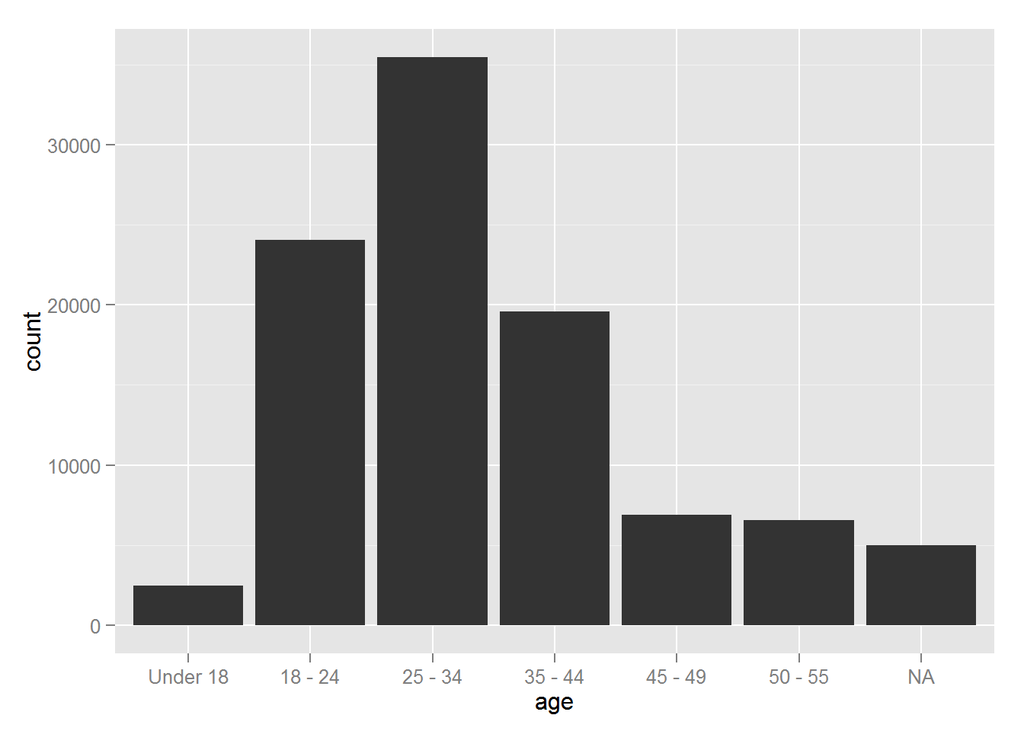

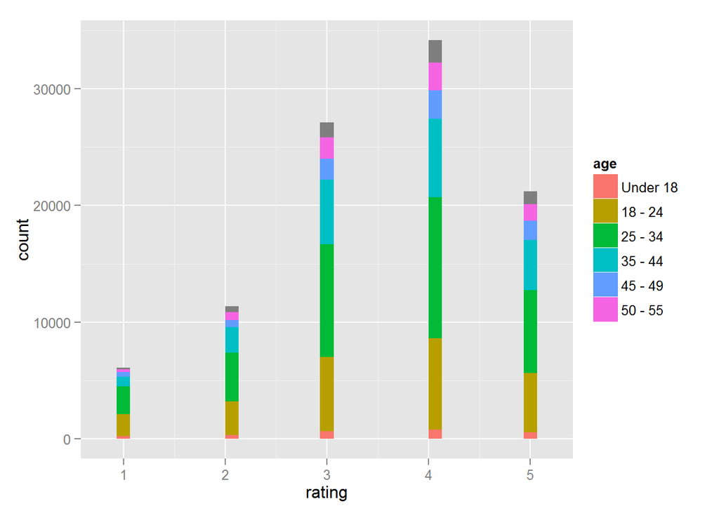

At this point, I am considering removing movietitle but will leave it in there for now. My reason is because I see two possible models that could be built. One model could be to learn how a particular user rates movies based on the characteristics of the movies they’ve rated and then predict how they’d rate new movies based on the new movie’s characteristics with the end result being that the model recommends to them the movies the algorithm predicts they would have rated highly. In this case, the name of the movie the user rated is not important and thus can be removed, its characteristics however are important, and here getting more information on the movie from imdb would really help. This model is user-centric and wouldn’t be useful until the user has seen and rated enough movies.

Another possible model would be to not be user-specific but to instead be userinfo-specific, what this means is to learn not on the particular user, but on the user’s information like age, occupation e.t.c While this would be a much less restrictive algorithm in that it doesn’t require that the user rate a lot of movies to begin with because it predicts based on the user’s info as opposed to the particular user, the downside here is that we are making an assumption that users with a similar background would rate particular movies similarly, this kind of assumption would only really be justified if we had a lot of personal information. There however is no harm in trying and see how well it does.

A different albeit more difficult model would be to use an unsupervised learning algorithm to somehow divide up the users into specific classes(clusters) with each cluster representing movie tastes/preferences. This would be a more general implementation as it wouldn’t require the ratings column to make it’s predictions.

For the first implementation, I’m splitting the dataset into 3, the train set, a cross-validation set as well as a test set, the reason for this is to detect if the algorithm is overfitting. I will run this using a boosted decision tree and report the errors for all three. I’ll be using two different metrics to measure the error, the mean absolute error and the root mean square error. Both these metrics are great for this kind of problem.

A first run gives really good errors:

## Train set

| Mean Absolute Error | Root Mean Squared Error |
| --- | --- |
| 0.651983 | 0.932193 |

## CV Set

| Mean Absolute Error | Root Mean Squared Error |
| --- | --- |
| 0.708 | 0.994736 |

## Test Set

| Mean Absolute Error | Root Mean Squared Error |
| --- | --- |
| 0.7118 | 0.99955 |

There is a difference between the Train set errors and both the CV and test set errors but not enough to suggest overfitting.

While there is plenty of opportunity to tune the parameters and possibly get a lower error, the error given is good enough for what it’s needed for.

Below is a residual vs fitted plot for each of the sets , this lets us see how the algorithm is performing on what it’s predicting right and wrong. All the points at zero are the examples predicted correctly for that particular prediction with the predictions around zero how much wrong the predictions are.

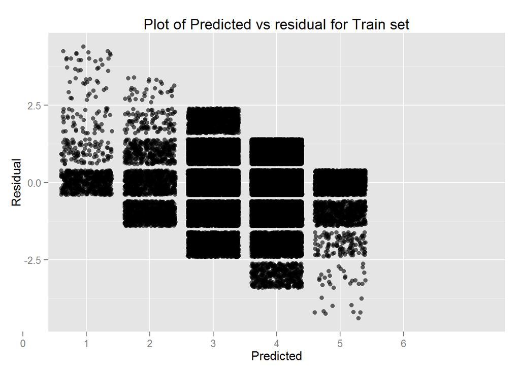

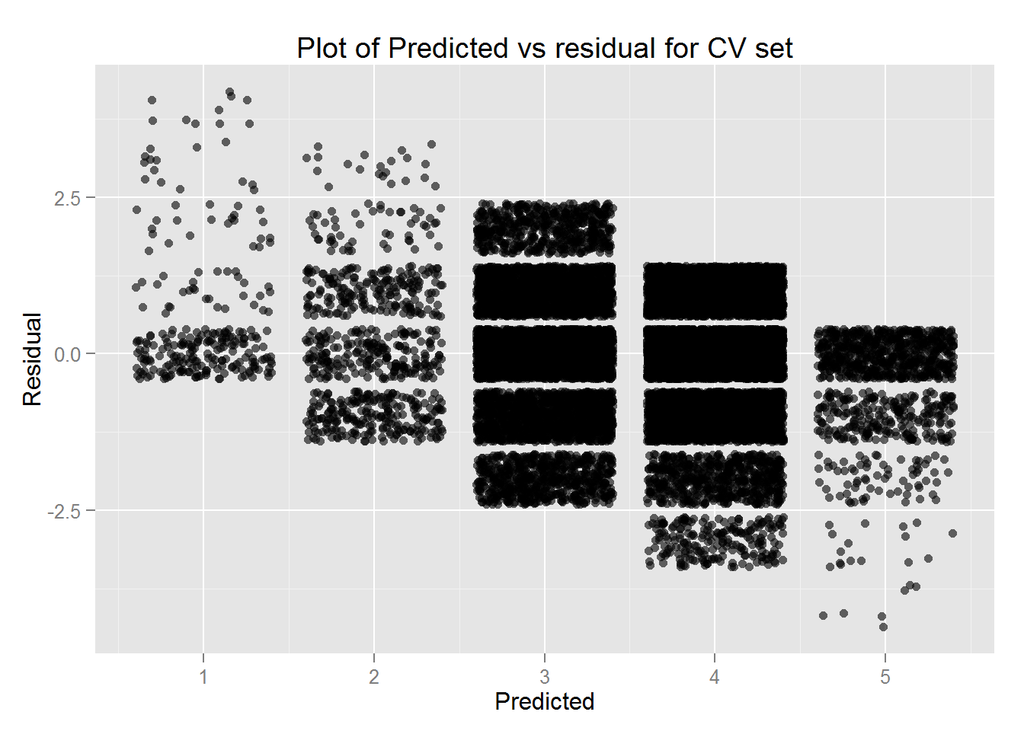

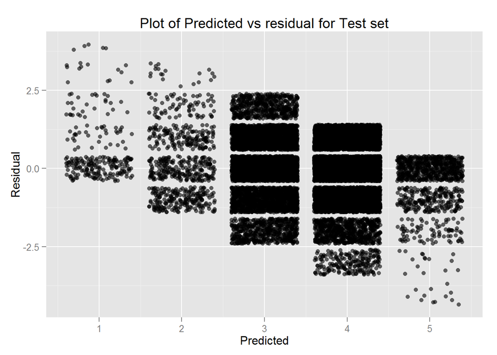

```
##    actual predicted
## 1       3         3
## 2       2         3
## 3       4         4
## 4       3         4
## 5       3         3
## 6       2         4
## 7       2         3
## 8       3         4
## 9       3         4
## 10      2         3
## 11      5         3
## 12      3         3
## 13      5         4
## 14      5         4
## 15      3         3
## 16      4         4
## 17      4         4
## 18      4         4
## 19      3         3
## 20      4         4
## 21      3         5
## 22      3         4
## 23      4         3
## 24      4         4
## 25      4         4
```

While it is possible to fine tune and boost the performance of this algorithm a bit more, the results we get aren’t actually that bad which means given enough ratings by a particular customer, we can predict with a relatively high confidence, what other movies they likely would rate highly.

The second and third part of this project would be trying to implement the two other ideas discussed earlier.